# HomeworkG-numericalIntegration

```python
#importing the usual libraries and modules
import matplotlib.pyplot as plt
import numpy as np
```

## 2 Testing I have access to the module by running

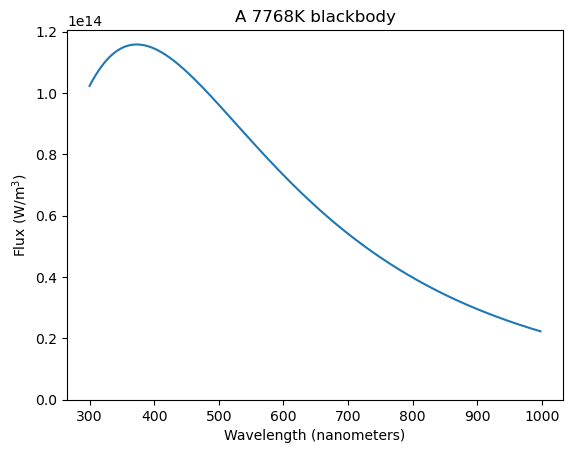

```python
#testing to make sure I have blackbody.py in the correct area of my jupyter notebook
# I also imported thermal.oy and constants.py into my jupyter notebook
import blackbody
blackbody.testBlackbody()
```

the above code seems to have generated a blackbody diagram with wavelength in nanometers on the x-axis and fluux in watts per meter**3 on the y-axis

```python
#learning what the blackbody() module does
help(blackbody)
```

```
Help on module blackbody:

NAME
    blackbody - This module contains tools to generate random blackbody spectra.

FUNCTIONS
    generateBlackbody(T='random')
        Generate a blackbody spectrum for a random (or specific) temperature.

            Arguments:

                T = [Optional]If set, this temperature is used to generate the
                    blackbody curve. If not, a random temperature is generated
                    between 2000-9000K.

            Returns:

                A blackbody spectrum. The format of this spectrum
                is as a dictionary that contains several key-value pairs.
                The keys inside this spectrum are highlighted in
                the example below.

            Example:

                # call the function to get a random spectrum
                s = generateBlackbody()

                # the wavelengths are in units of nanometers (=10**-9 m)
                w_nanometers = s['wavelengths']

                # the fluxes are in units of "W/m**3"
                f = s['flux']

                # The temperature used for the Planck function is in Kelvin"
                t = s['temp']

                # A title for the object is given in a string named objectID
                name = s['objectID']

    testBlackbody()
        This function tests the generateBlackbody() function and plots the result.
            Arguments:
                None

            Returns:
                Nothing

            Example:
                testBlackbody()

FILE
    /home/luel8892/ASTR 2600/homework/blackbody.py
```

```python
black_body = blackbody.generateBlackbody(T='random')
print(len(black_body)) #learing how many coloumns blackbody has
print(type(black_body)) #learning what the type blackbody is is
```

```
4
<class 'dict'>
```

```python
print(black_body.keys()) #learning what the keys of black body are
```

```
dict_keys(['temp', 'wavelengths', 'flux', 'objectID'])
```

```python
print(type(black_body['temp']))
```

```
<class 'numpy.float64'>
```

## 3 Python function called integrateSpectrum

```python
def integrateSpectrum(wavelengths, fluxes, w_lower, w_upper):

    """
    This function performs a numerical integral of a spectrum.
    Arguments:
    wavelengths = a numpy array of wavelengths, in nanometers
    fluxes = a numpy array of fluxes, corresponding to w
    w_lower = the lower wavelength limit of the integration
    w_upper = the upper wavelength limit of the integration
    Returns:
    the integral of fluxes, with wavelength limits from w_lower to w_upper
    (this should be one floating point number)
    """
    new_wavelengths = []#creating a new list for the wavelengths between w_lower and w_upper
    new_fluxes = []#list pf equal length to new_wvalengths for teh fluxes at each point in the domain, between w_lower to w_upper

    for i in range(len(wavelengths)):#adding all of the  wavelengths and fluxes between w_lower and w_upper to tjhe new lists
        if w_lower <= wavelengths[i] <= w_upper:
            new_wavelengths.append(wavelengths[i])
            new_fluxes.append(fluxes[i])

    delta_wave = (w_upper-w_lower)/len(new_wavelengths) #calculating the duffeerence between succseive wavelength values

    trap_area = []
    for i in range(len(new_wavelengths)-1):#len(new_wavelengths)-1): #calulating the trapeziodal integral
        trap_area.append(((new_fluxes[i]+new_fluxes[i+1])/2)*delta_wave)
        #print(f"\n \n at i = {i} \n trap_area = {trap_area[i]}")

    trap_area = np.array(trap_area)
    #print(f" \n {delta_wave}")
    #return delta_wave
    return np.sum(trap_area)
```

## 4 testing my function

I ran part of this code while creating my function

```python
imaginary_w = np.sort(np.random.uniform(400, 1000, 1000)) #creating a numpy array of tesat wavelngths
imaginary_f = imaginary_w # creating a numpy array for fluxes to test
w_low = 600 #creating the lower bound for the domain of wavelengths to integrate
w_up = 700 #creating the upper  bound for the domain of wavelengths to integrate
```

```python
#testing trapezoidal integration using these numbers

imaginary_w = np.sort(np.linspace(1, 10, 10)) #creating a numpy array of tesat wavelngths
imaginary_f = imaginary_w # creating a numpy array for fluxes to test
w_low = 1 #creating the lower bound for the domain of wavelengths to integrate
w_up = 11 #creating the upper  bound for the domain of wavelengths to integrate
print(imaginary_w)
```

```
[ 1.  2.  3.  4.  5.  6.  7.  8.  9. 10.]
```

```python
#testing the integrateSpectrum with y -x from x=- to x =10 with 10 subdivisions. This should return 49.5
integrateSpectrum(imaginary_w, imaginary_f,w_low, w_up ) #
```

[output not shown]

```
49.5
```

Okay, so my integrateSpectrum function using the Riemann trapezoid rule seems to be working!

```python
imaginary_w = np.sort(np.random.uniform(400, 1000, 1000)) #creating a numpy array of tesat wavelngths
imaginary_f = imaginary_w # creating a numpy array for fluxes to test
w_low = 600 #creating the lower bound for the domain of wavelengths to integrate
w_up = 700 #creating the upper  bound for the domain of wavelengths to integrate
```

```python
print(f"{integrateSpectrum(imaginary_w, imaginary_f,w_low, w_up )} watts/(meter**3)")
#running integrateSpectrum from 600 to 700 nm
```

```
64503.69655012342 watts/(meter**3)
```

## 5 integrating to calculate RGB

```python
#getting the wavelength and flux values from the black_body dictionary
wavelengths = np.array(black_body['wavelengths'])
flux = np.array(black_body['flux'])

print(len(wavelengths) == len(flux)) #making sure the two np.arrays are teh same length
```

```
True
```

```python
red = integrateSpectrum(wavelengths, flux, 565, 660) #getting the red values from 565 nm to 660 nm
```

```python
green = integrateSpectrum(wavelengths, flux, 480, 570) #getting the green values from 480 nm to 570 nm
```

```python
blue = integrateSpectrum(wavelengths, flux, 400, 490) #getting the blue values from 400 nm to 490 nm
```

```python
def estimateRGB(wavelengths, fluxes):

    """
    This function estimates the RGB color of an object, from its spectrum.
    It calculates the integrals the flux over wavelength ranges
    that correspond roughly to the red, green, and blue colors
    displayed on computer monitors.

    Arguments:
    wavelengths = a numpy array of wavelengths, in nanometers
    fluxes = a numpy array of fluxes, corresponding to w

    Returns:
    an RGB color, expressed as a three-element array,
    with R as the first element, G the second, B the third
    (In Python these values must span from 0.0 to 1.0, so you
    will need to renormalize your integrals by the maximum of
    the three values, to ensure this happens.)
    """

    red = integrateSpectrum(wavelengths, flux, 565, 660) #getting the red values from 565 nm to 660 nm

    green = integrateSpectrum(wavelengths, flux, 480, 570) #getting the green values from 480 nm to 570 nm

    blue = integrateSpectrum(wavelengths, flux, 400, 490) #getting the blue values from 400 nm to 490 nm


    #figuring out wich color is greatest
    if red > green and red > blue: #red is the greatest and will therefore have a value of 1 in the RGB list
        #print(f" red = {red} \n green = {green} \n blue = {blue}")

        R = red/red
        G = green/red
        B = blue/red
        RGB = [R,G,B]
        return RGB

    elif green > red and green > blue:#green is the greatest and will therefore have a value of 1 in the RGB list
        #print(f" green = {green}\n red = {red} \n blue = {blue}")
        G = green/green
        R = red/green
        B = blue/green
        RGB = [R,G,B]
        return RGB

    elif blue > red and blue > green:#blue is the greatest and will therefore have a value of 1 in the RGB list
        #print(f"blue = {blue} \n green = {green}\n red = {red}")
        B = blue/blue
        R = red/blue
        G = green/blue
        RGB = [R,G,B]

        return RGB
```

```python
estimateRGB(wavelengths, flux)
```

```
[0.7065578219023919, 0.8421778849357727, 1.0]
```

## 6 testing my RGB function

```python
#redifing imaginary_w and imaginary_f to see if I accidentally changed thier defintions earlier
imaginary_w = np.sort(np.random.uniform(400, 1000, 1000))
imaginary_f = imaginary_w
print(integrateSpectrum(imaginary_w, imaginary_f, 600, 700))
```

```
64680.25522632939
```

```python
print(estimateRGB(imaginary_w, imaginary_f))
```

```
[0.7821994423781864, 0.9518197471760547, 1.0]
```

I do not know why I am not getting the correct answer of [ 1.0, 0.78, 0.69].

## 7 generate a blackbody spectrum of a randomly generated temperature

At the very beginning of the homework, I called help(blackbody) in line [19]. I was confused about what blackbody was doing and I wanted to better understand it. So I know I can call generateBlackbody(T='random')

```python
firstspectrum = blackbody.generateBlackbody(T='random')
```

```python
print(type(firstspectrum)) #this should tell me the data type of firstspectrum
```

```
<class 'dict'>
```

```python
print(firstspectrum.keys())
```

```
dict_keys(['temp', 'wavelengths', 'flux', 'objectID'])
```

Since firstspectrum has data type: dictionary, I should be able to extract all of the wavelengths and fluxes by simply extracting all of the elements under the keys, 'wavelengths' and 'flux' similar to what I did in [199]

as stated when I called help(blackbody) on line [19], # the wavelengths are in units of nanometers (=10**-9 m)

and ,# the fluxes are in units of "W/m**3"

```python
#just the code from [199]
wavelengths = np.array(firstspectrum['wavelengths'])
flux = np.array(firstspectrum['flux'])
```

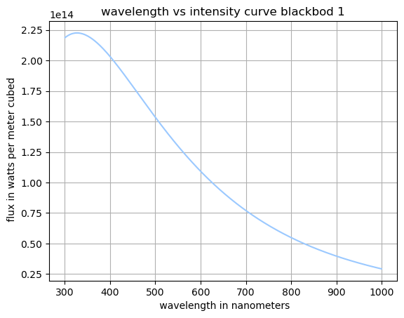

```python
plt.plot(wavelengths,flux, color = estimateRGB(wavelengths, flux))
plt.xlabel(" wavelength in nanometers")
plt.ylabel(" flux in watts per meter cubed")
plt.title("wavelength vs intensity curve blackbod 1")
plt.grid()
```

## 8 making ten plots of randomly generated black body spectra

I'm using the first plot as plot #1 in this list of 10 randomly generated plots

```python
firstspectrum = blackbody.generateBlackbody(T='random') #i'm just copying and pasting the code as each new defintion will create new values
```

```python
#just the code from [199]
wavelengths = np.array(firstspectrum['wavelengths'])
flux = np.array(firstspectrum['flux'])
```

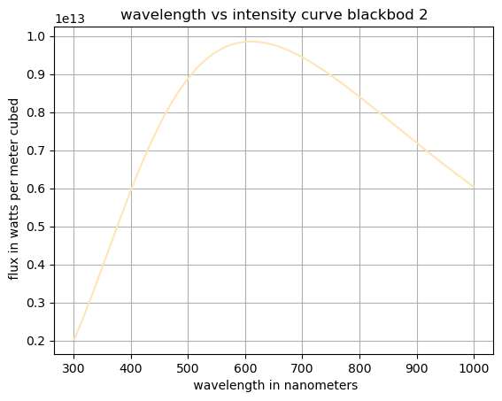

```python
plt.plot(wavelengths,flux, color = estimateRGB(wavelengths, flux))
plt.xlabel(" wavelength in nanometers")
plt.ylabel(" flux in watts per meter cubed")
plt.title("wavelength vs intensity curve blackbod 2")
plt.grid()
```

```python
firstspectrum = blackbody.generateBlackbody(T='random')
```

```python
#just the code from [199]
wavelengths = np.array(firstspectrum['wavelengths'])
flux = np.array(firstspectrum['flux'])
```

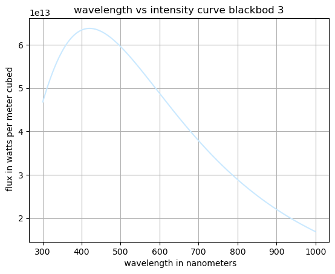

```python
plt.plot(wavelengths,flux, color = estimateRGB(wavelengths, flux))
plt.xlabel(" wavelength in nanometers")
plt.ylabel(" flux in watts per meter cubed")
plt.title("wavelength vs intensity curve blackbod 3")
plt.grid()
```

```python
firstspectrum = blackbody.generateBlackbody(T='random')
```

```python
#just the code from [199]
wavelengths = np.array(firstspectrum['wavelengths'])
flux = np.array(firstspectrum['flux'])
```

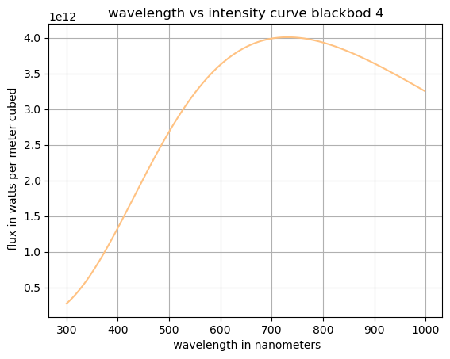

```python
plt.plot(wavelengths,flux, color = estimateRGB(wavelengths, flux))
plt.xlabel(" wavelength in nanometers")
plt.ylabel(" flux in watts per meter cubed")
plt.title("wavelength vs intensity curve blackbod 4")
plt.grid()
```

```python
firstspectrum = blackbody.generateBlackbody(T='random')
```

```python
#just the code from [199]
wavelengths = np.array(firstspectrum['wavelengths'])
flux = np.array(firstspectrum['flux'])
```

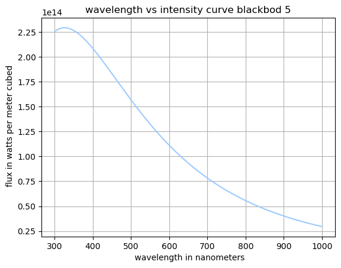

```python
plt.plot(wavelengths,flux, color = estimateRGB(wavelengths, flux))
plt.xlabel(" wavelength in nanometers")
plt.ylabel(" flux in watts per meter cubed")
plt.title("wavelength vs intensity curve blackbod 5")
plt.grid()
```

```python
firstspectrum = blackbody.generateBlackbody(T='random')
```

```python
#just the code from [199]
wavelengths = np.array(firstspectrum['wavelengths'])
flux = np.array(firstspectrum['flux'])
```

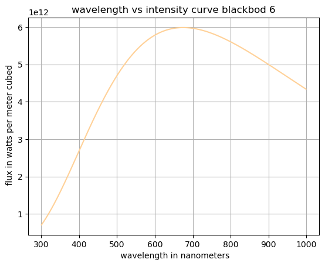

```python
plt.plot(wavelengths,flux, color = estimateRGB(wavelengths, flux))
plt.xlabel(" wavelength in nanometers")
plt.ylabel(" flux in watts per meter cubed")
plt.title("wavelength vs intensity curve blackbod 6")
plt.grid()
```

```python
firstspectrum = blackbody.generateBlackbody(T='random')
```

```python
#just the code from [199]
wavelengths = np.array(firstspectrum['wavelengths'])
flux = np.array(firstspectrum['flux'])
```

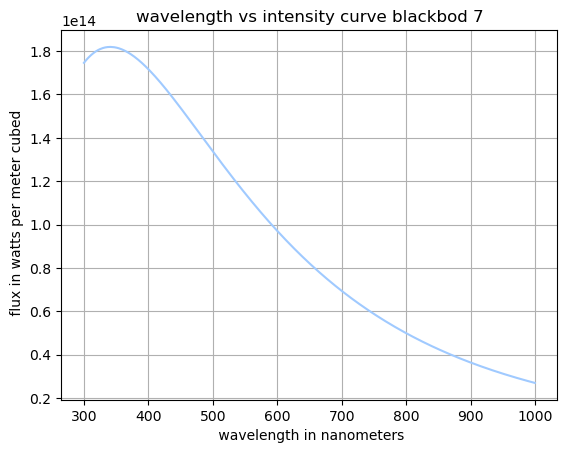

```python
plt.plot(wavelengths,flux, color = estimateRGB(wavelengths, flux))
plt.xlabel(" wavelength in nanometers")
plt.ylabel(" flux in watts per meter cubed")
plt.title("wavelength vs intensity curve blackbod 7")
plt.grid()
```

```python
firstspectrum = blackbody.generateBlackbody(T='random')
```

```python
#just the code from [199]
wavelengths = np.array(firstspectrum['wavelengths'])
flux = np.array(firstspectrum['flux'])
```

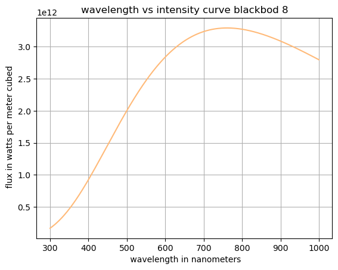

```python
plt.plot(wavelengths,flux, color = estimateRGB(wavelengths, flux))
plt.xlabel(" wavelength in nanometers")
plt.ylabel(" flux in watts per meter cubed")
plt.title("wavelength vs intensity curve blackbod 8")
plt.grid()
```

```python
firstspectrum = blackbody.generateBlackbody(T='random')
```

```python
#just the code from [199]
wavelengths = np.array(firstspectrum['wavelengths'])
flux = np.array(firstspectrum['flux'])
```

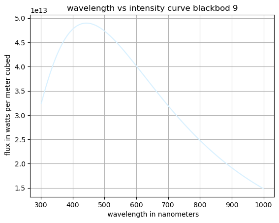

```python
plt.plot(wavelengths,flux, color = estimateRGB(wavelengths, flux))
plt.xlabel(" wavelength in nanometers")
plt.ylabel(" flux in watts per meter cubed")
plt.title("wavelength vs intensity curve blackbod 9")
plt.grid()
```

```python
firstspectrum = blackbody.generateBlackbody(T='random')
```

```python
#just the code from [199]
wavelengths = np.array(firstspectrum['wavelengths'])
flux = np.array(firstspectrum['flux'])
```

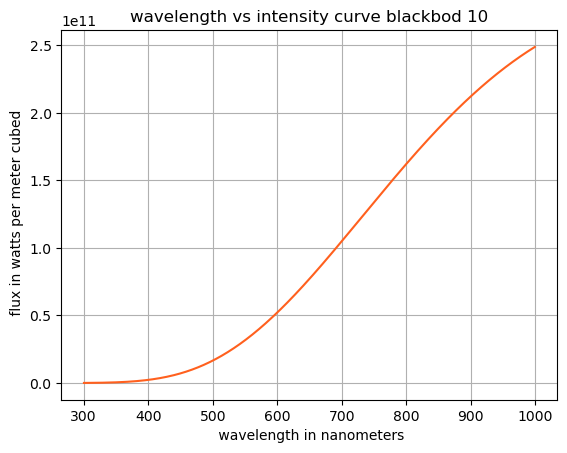

```python
plt.plot(wavelengths,flux, color = estimateRGB(wavelengths, flux))
plt.xlabel(" wavelength in nanometers")
plt.ylabel(" flux in watts per meter cubed")
plt.title("wavelength vs intensity curve blackbod 10")
plt.grid()
```

## 9

I'm noticing two clear and distinct patterns in the plots. If the peak wavlength is longer (greater wavelength in nanometers) the RGB value looks redder. Likewise, if the peak wavelength is shorter (lower wavelength in nanometers), the RGB value looks bluer.

## 10 generate three blackbody spectra of specific temperatures: 5000K, 10,000K, 20,000K.

```python
fivek = blackbody.generateBlackbody(T=5000)
tenk = blackbody.generateBlackbody(T=10000)
twentyk = blackbody.generateBlackbody(T=20000)
```

```python
wavelengths = np.array(fivek['wavelengths'])
flux = np.array(fivek['flux'])
fivebright =  integrateSpectrum(wavelengths, flux, 400, 700)
print(f"{fivebright:.4e}")
```

```
3.5633e+15
```

```python
wavelengths = np.array(tenk['wavelengths'])
flux = np.array(tenk['flux'])
tenbright =  integrateSpectrum(wavelengths, flux, 400, 700)
print(f"{tenbright:.4e}")
```

```
5.9461e+16
```

```python
wavelengths = np.array(twentyk['wavelengths'])
flux = np.array(twentyk['flux'])
twentybright =  integrateSpectrum(wavelengths, flux, 400, 700)
print(f"{twentybright:.4e}")
```

```
3.1389e+17
```